# Research Project Questions

DATA5207: Data Analysis in the social sciences

December 16, 2024

# Introduction

The monitoring of health statistics forms creates a strong foundation for the tracking of the general population health and guides policy formulation around matters health, as Krieger et al., (1997) point out. The collection of health statistics extended to socio-economic aspects ever since Massachusetts became the first state in 1842 to formally adopt it. Various studies have been undertaken to map out the relation between health metrics and socio-economic aspects, including (Braveman et al., 2010) checking on education, income levels and race and found that the least educated and lower income groupings were often associated with lower health status.

Adler & Newman, (2002) review socio-economic status, and the associated impact on health. Access to education eases the promotion of health information to individuals, access to income provides avenue for better nutrition, access to education and housing needs. Occupation on the other hand provides access to health related benefits, while also providing exposures to physical injuries for certain occupations.

The main objective of the analysis undertaken herein is pointing out the predictors for better health outcomes at the county level in the United States. The relationship existing between various variables is assessed and how they generally influence the number of deaths among United States of America county residents under age 75 per 100,000 population (age-adjusted).

The dependent variable is the premature age-adjusted mortality variable, while the predictor variables are selected based on previous research (Cheng & Kindig, 2012). The predictor will include variables with information on income and income inequality, population, demography aspects including race, health care costs and associated level of access, and numbers on primary care providers, preventable hospitalizations, high school graduation rates and college education levels, the percentage of single-parent households, and children living in poverty guidelines, and finally percentages of adult obesity and smoking.

# Methods

A multiple linear regression model is used to investigate the existing relation between the premature age-adjusted mortality variable and its explanatory variables. The data of different health outcomes at the level of US counties, is obtained from the Robert Wood Johnson Foundation and the University of Wisconsin Population Health Institute.

## Data Information

The data contains 3142 observations and 20 features.

### Measures

Dependent Variables: `Premature age-adjusted mortality`

Independent Variables:

- Median household income: Small Area Income and Poverty Estimates
- Income inequality: Ratio of household income at the 80th percentile to income at the 20th percentile
- Population
- % Non-Hispanic African American:
- % American Indian and Alaskan Native:
- % Asian:
- % Native Hawaiian/Other Pacific Islander:
- % Hispanic:
- % Non-Hispanic white:
- Uninsured adults:
- Health care costs
- Other primary care providers
- Preventable hospital stays: Number of hospital stays for ambulatory-care sensitive conditions per 1,000 Medicare enrollees
- High school graduation: Percentage of ninth-grade cohort that graduates in four years
- Some college: Percentage of adults ages 25-44 with some post-secondary education
- Children in single-parent households: Percentage of children that live in a household headed by single parent
- Children in poverty: Percentage of children under age 18 in poverty
- Adult smoking: Percentage of adults who are current smokers
- Adult obesity: Percentage of adults that report a BMI of 30 or more

## Descriptive Statistics

Summary statistics of the data is as below:

```
-------------------------------------------------------------
 age_adjusted_mortality   household_income     population
------------------------ ------------------ -----------------
     Min.  : 133.0         Min.  : 22045       Min.  : 88

     1st Qu.: 323.1        1st Qu.: 41072    1st Qu.: 10976

     Median : 388.3        Median : 47589    Median : 25771

      Mean : 401.3          Mean : 49522      Mean : 102841

     3rd Qu.: 470.9        3rd Qu.: 55308    3rd Qu.: 67490

     Max.  :1142.6         Max.  :134609     Max.  :10137915

        NA's :65              NA's :1              NA
-------------------------------------------------------------

Table: Table continues below


-------------------------------------------------------------------
 percent_african_american   percent_american_indian_alaskan_native
-------------------------- ----------------------------------------
      Min.  : 0.0000                    Min.  : 0.0000

     1st Qu.: 0.6662                   1st Qu.: 0.3609

     Median : 2.1734                   Median : 0.6105

      Mean : 8.9426                     Mean : 2.3093

     3rd Qu.:10.0817                   3rd Qu.: 1.3053

      Max.  :85.1516                    Max.  :93.0675

            NA                                NA
-------------------------------------------------------------------

Table: Table continues below
```

[output cut: 88 more lines]

```
----------------------------- --------------- -----------------
        Min.  : 2.90           Min.  :12.80     Min.  : 6.735

        1st Qu.:15.60          1st Qu.:28.80   1st Qu.:15.235

        Median :21.30          Median :31.80   Median :17.321

         Mean :22.37            Mean :31.47     Mean :17.873

        3rd Qu.:27.90          3rd Qu.:34.40   3rd Qu.:20.280

        Max.  :66.30           Max.  :47.80     Max.  :42.754

           NA's :1                  NA               NA
---------------------------------------------------------------
```

### Exploratory Analysis

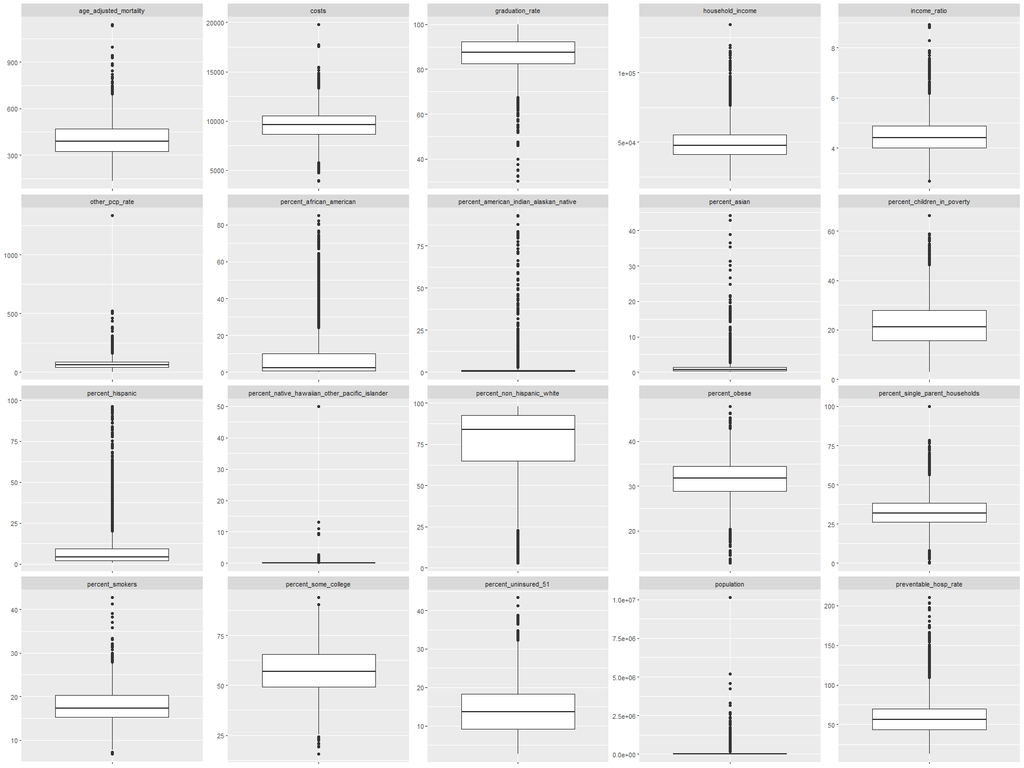

### Correlation Analysis

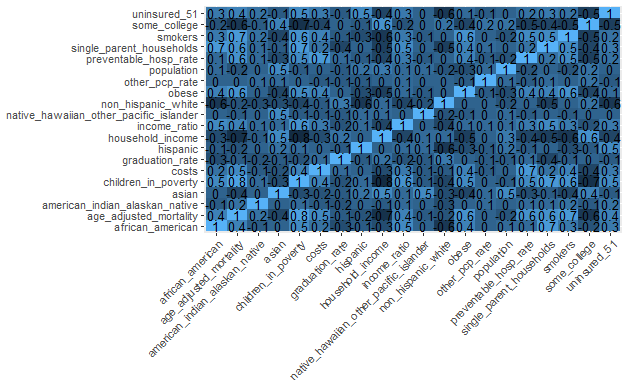

## Model Fitting

| term | estimate | p.value |
| --- | --- | --- |
| (Intercept) | 583.3315756 | 0.0000047 |
| household_income | -0.0005119 | 0.0056913 |
| population | -0.0000075 | 0.0368519 |
| percent_african_american | -5.5871238 | 0.0000045 |
| percent_american_indian_alaskan_native | -4.5741249 | 0.0003098 |
| percent_asian | -6.7136490 | 0.0000029 |
| percent_native_hawaiian_other_pacific_islander | -4.5601726 | 0.2536166 |
| percent_hispanic | -6.2382143 | 0.0000001 |
| percent_non_hispanic_white | -5.2450414 | 0.0000184 |
| percent_uninsured_51 | 1.3832088 | 0.0000005 |
| costs | 0.0112580 | 0.0000000 |
| other_pcp_rate | 0.0960971 | 0.0000197 |
| income_ratio | 5.5144600 | 0.0074830 |
| preventable_hosp_rate | 0.4208420 | 0.0000000 |
| graduation_rate | -0.0875965 | 0.5631576 |
| percent_some_college | -0.9917633 | 0.0000000 |
| percent_single_parent_households | 1.2294889 | 0.0000000 |
| percent_children_in_poverty | 3.4167606 | 0.0000000 |
| percent_obese | 2.2109633 | 0.0000000 |
| percent_smokers | 3.7975199 | 0.0000000 |

| r_squared | adj_r_squared | sigma | p_value | nobs |
| --- | --- | --- | --- | --- |
| 0.7447771 | 0.7429113 | 54.11637 | 0 | 2619 |

## Model Diagnostics

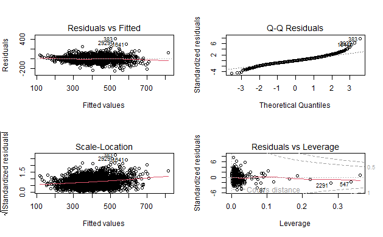

# Results

The summary statistics depict variables with missing data points, of which the observations were automatically excluded from the multiple linear regression model. The correlation plot depicts strong positive linear relationship between `Premature age-adjusted mortality` and `Percentage of children under age 18 in poverty` at 0.8, and negative with `Median household income` at -0.7.

For the variables with positive coefficients, interpretations can be made that a unit increase is associated with the coefficient value increase in the premature age mortality. Similarly, for the variables with negative coefficients, interpretations can be made that a unit increase is associated with the coefficient value decrease in the premature age mortality. The analysis undertaken is limited to only the data provided from the Robert Wood Johnson Foundation and the University of Wisconsin Population Health Institute and extensive analysis can be undertaken to include other variables, datasets or models of interest that may capture the influence of socio-economic attributes on premature age mortality.

# References

Adler, N. E., & Newman, K. (2002). Socioeconomic disparities in health: Pathways and policies. Health Affairs, 21(2), 60–76. https://doi.org/10.1377/hlthaff.21.2.60

Braveman, P. A., Cubbin, C., Egerter, S., Williams, D. R., & Pamuk, E. (2010). Socioeconomic disparities in health in the United States: What the patterns tell us. American Journal of Public Health, 100(S1). https://doi.org/10.2105/ajph.2009.166082

Cheng, E., & Kindig, D. (2012). Disparities in premature mortality between high- and low-income US counties. Preventing Chronic Disease. https://doi.org/10.5888/pcd9.110120

Jobson, J. D., & Jobson, J. D. (1991). Multiple linear regression. Applied multivariate data analysis: regression and experimental design, 219-398.

Krieger, N., Chen, J. T., & Ebel, G. (1997). Can we monitor socioeconomic inequalities in health? A survey of US health departments’ data collection and reporting practices. Public health reports, 112(6), 481.

Premature age-adjusted mortality*. County Health Rankings & Roadmaps. (n.d.-a). https://www.countyhealthrankings.org/health-data/health-outcomes/length-of-life/premature-age-adjusted-mortality?year=2024